# Local Interpretation Methods

In-class exercise 08-1

# Goal

Apply what you have learned about local interpretation methods to real data.

# Prerequisites

We need the following libraries:

```r
library('randomForest')
library('iml')
library("rchallenge")
library("counterfactuals")
```

# Data

### German Credit

```r
data(german, package = "rchallenge")
credit = german[, c("duration", "amount", "purpose", "age",
  "employment_duration", "housing", "number_credits", "credit_risk")]
```

### Wine

In the data set are quality ratings (assessed by blind tasting, on a scale from 0 to 10) for roughly 6500 red and white wines with given physiochemical properties:

```r
wine = read.csv("wine.csv")
wine = na.omit(wine)
wine$type = as.factor(wine$type)
str(wine)
```

```
## 'data.frame':    6463 obs. of  13 variables:
##  $ type                : Factor w/ 2 levels "red","white": 2 2 2 2 2 2 2 2 2 2 ...
##  $ fixed.acidity       : num  7 6.3 8.1 7.2 7.2 8.1 6.2 7 6.3 8.1 ...
##  $ volatile.acidity    : num  0.27 0.3 0.28 0.23 0.23 0.28 0.32 0.27 0.3 0.22 ...
##  $ citric.acid         : num  0.36 0.34 0.4 0.32 0.32 0.4 0.16 0.36 0.34 0.43 ...
##  $ residual.sugar      : num  20.7 1.6 6.9 8.5 8.5 6.9 7 20.7 1.6 1.5 ...
##  $ chlorides           : num  0.045 0.049 0.05 0.058 0.058 0.05 0.045 0.045 0.049 0.044 ...
##  $ free.sulfur.dioxide : num  45 14 30 47 47 30 30 45 14 28 ...
##  $ total.sulfur.dioxide: num  170 132 97 186 186 97 136 170 132 129 ...
##  $ density             : num  1.001 0.994 0.995 0.996 0.996 ...
##  $ pH                  : num  3 3.3 3.26 3.19 3.19 3.26 3.18 3 3.3 3.22 ...
##  $ sulphates           : num  0.45 0.49 0.44 0.4 0.4 0.44 0.47 0.45 0.49 0.45 ...
##  $ alcohol             : num  8.8 9.5 10.1 9.9 9.9 10.1 9.6 8.8 9.5 11 ...
##  $ quality             : int  6 6 6 6 6 6 6 6 6 6 ...
##  - attr(*, "na.action")= 'omit' Named int [1:34] 18 34 55 87 99 140 175 225 250 268 ...
##   ..- attr(*, "names")= chr [1:34] "18" "34" "55" "87" ...
```

# Fit a Random Forest

```r
set.seed(124)
ids = sample(1:nrow(wine), size = 500, replace = FALSE)
train = wine[-ids,]
test = wine[ids,]

# Fit random forest:
forest = randomForest(quality ~ ., data = train)
forest
```

```
##
## Call:
##  randomForest(formula = quality ~ ., data = train)
##                Type of random forest: regression
##                      Number of trees: 500
## No. of variables tried at each split: 4
##
##           Mean of squared residuals: 0.3470765
##                     % Var explained: 54.77
```

# Exercises

In the following exercises, we shall always compute interpretations on the test data.

## Exercise 1: Predictor Objects in `iml`

The interpretation methods in `iml` require the model and data to be wrapped in a `Predictor` object. Create a `Predictor` object for the `wine` (test) data and the `forest` model.

**Hint 1:**

Checkout the help page `?Predictor` to understand how to construct the `Predictor` object.

### Solution:

**Click me:**

```r
rfpred = Predictor$new(forest, data = test, y = "quality")
```

## Exercise 2: LIME

LIME (Local Interpretable Model-Agnostic Explanations) is a technique used to explain individual predictions of any machine learning model by approximating it locally with an interpretable model. This simplification helps identify which features contribute most to a specific prediction, providing valuable insights into model behavior. Let’s create a `LocalModel` object, an R6 class in `iml`, to explain the random forest prediction for the first observation in the test data with a linear regression model. The results will be stored in the field `$results`.

**Hint 1:**

Checkout the help page `?LocalModel` to understand how to construct the `LocalModel` object. The details section explains the explicit method used.

### Solution:

**Click me:**

```r
lime <- LocalModel$new(rfpred, x.interest = test[1, ])
lime$results
```

```
##                         beta x.recoded      effect x.original          feature         feature.value
## volatile.acidity -0.89712781      0.35 -0.31399473       0.35 volatile.acidity volatile.acidity=0.35
## sulphates         0.08489574      0.91  0.07725512       0.91        sulphates        sulphates=0.91
## alcohol           0.29602289     11.00  3.25625181         11          alcohol            alcohol=11
```

This can also be visualized:

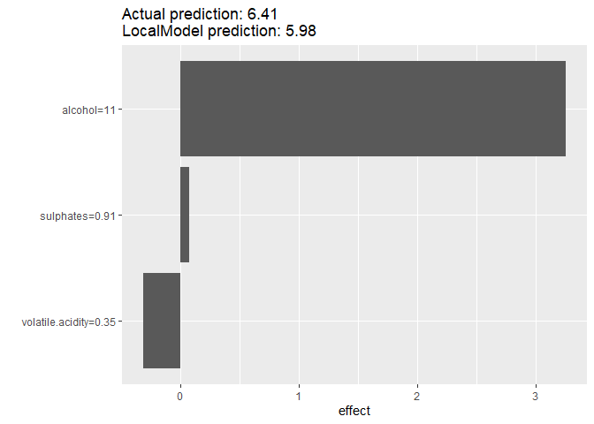

```r
plot(lime)
```

## Exercise 3: ICE

Individual Conditional Expectation (ICE) plots display one line per instance that shows how the instance’s prediction changes when a feature changes. An ICE plot visualizes the dependence of the prediction on a feature for each instance separately, resulting in one line per instance, compared to one line overall in partial dependence plots (PDP). Create an ICE plot for the feature `alcohol` with the class `FeatureEffect`. Describe the feature-target relationship you can observe from this.

### Solution:

**Click me:**

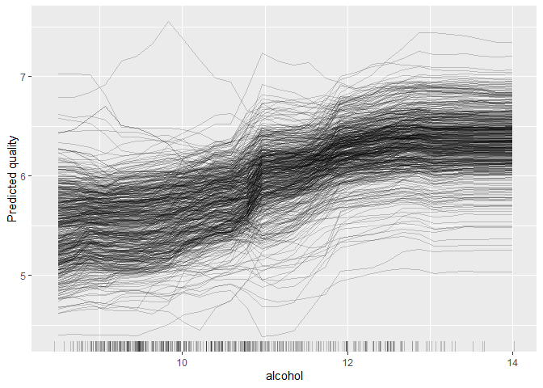

```r
ice <- FeatureEffect$new(predictor = rfpred,
                         feature = "alcohol",
                         method = "ice",
                         grid.size = 30)
plot(ice)
```

For most (but not all) observations, alcohol seems to positively influence predicted quality.

## Exercise 4: Counterfactual Explanations

Counterfactual explanations try to identify the smallest possible changes to the input features of a given observation that would lead to a different prediction. In other words, a counterfactual explanation provides an answer to the question: “What changes in the current feature values are necessary to achieve a different prediction?”. To do so, we first train a model to predict whether a credit is good or bad, omitting one observation from the training data, which is the individual for which we want to find such explanations later on.

```r
forest2 = randomForest(credit_risk ~ ., data = credit[-998L,])
```

Let’s use Multi-Objective Counterfactual (MOC) Explanations [Dandl et al. 2020](https://link.springer.com/chapter/10.1007/978-3-030-58112-1_31) to compute counterfactuals. The corresponding `counterfactuals` package builds upon `iml`, e.g. by using the `Predictor` objects:

```r
pred = Predictor$new(forest2, type = "prob")
x_interest = credit[998L, ]
pred$predict(x_interest)
```

```
##     bad  good
## 1 0.634 0.366
```

### 4a) Create a MOC object

Now, we want to examine which factors need to be changed to increase the predicted probability of being a good credit risk to more than 60%. Since we want to apply MOC to a classification model, we can initialize a `MOCClassif` object. Use the documentation to learn about the arguments required and construct a suitable object. We want the following things:

- Penalization: Individuals whose prediction is farther away from the desired prediction than epsilon should be penalized.
- A person’s `age` and `employment_duration` are non-actionable parameters, meaning that they cannot be changed. This should be considered.
- Set `quiet = TRUE`, `termination_crit = "genstag"` and `n_generations = 10L`.

### Solution:

**Click me:**

```r
moc_classif = MOCClassif$new(
  pred, epsilon = 0, fixed_features = c("age", "employment_duration"),
  quiet = TRUE, termination_crit = "genstag", n_generations = 10L
)
```

### 4b) Find counterfactuals

Now, use the `$find_counterfactuals()` method to find counterfactuals for `x_interest`. Remember that we aim to find counterfactuals with a predicted probability of being a good credit of at least 60%.

### Solution:

**Click me:**

```r
cfactuals = moc_classif$find_counterfactuals(
  x_interest, desired_class = "good", desired_prob = c(0.6, 1)
)
```

### 4c) Analyze counterfactuals

The resulting `Counterfactuals` object holds the counterfactuals in the `data` field and possesses several methods for their evaluation and visualization. Printing a `Counterfactuals` object gives an overview of the results:

```r
print(cfactuals)
## 63 Counterfactual(s)
##
## Desired class: good
## Desired predicted probability range: [0.6, 1]
##
## Head:
##    duration amount purpose age employment_duration housing number_credits
## 1:       21   6367  others  30            >= 7 yrs     own              1
## 2:       21   6564  others  30            >= 7 yrs     own              1
## 3:       16   6564  others  30            >= 7 yrs     own              1
```

The `$predict()` method returns the predictions for the counterfactuals:

```r
head(cfactuals$predict(), 3L)
```

```
##     bad  good
## 1 0.328 0.672
## 2 0.340 0.660
## 3 0.342 0.658
```

By design, not all counterfactuals generated with MOC have a prediction equal to the desired prediction. Inspect the docu for the `Counterfactuals` class to find a method that subsets counterfactuals to omit all counterfactuals that do not achieve the desired prediction.

### Solution:

**Click me:**

```r
cfactuals$subset_to_valid()
head(cfactuals$data)
```

```
##    duration amount purpose age employment_duration housing number_credits
## 1:       21   6367  others  30            >= 7 yrs     own              1
## 2:       21   6564  others  30            >= 7 yrs     own              1
## 3:       16   6564  others  30            >= 7 yrs     own              1
## 4:       21   6085  others  30            >= 7 yrs     own              1
## 5:       16   6642  others  30            >= 7 yrs     own              1
## 6:       17   6463  others  30            >= 7 yrs     own              1
```

# Summary

We learned how to implement interpretation methods for LIME, ICE and Counterfactuals.